# rTg4510 DMR Plots

1510295

NA

FALSE

chr11:118729286

5.98e-02

chr11

118729289

118729289

1

chr11_6231

1510296

NA

FALSE

chr11:118729289

4.91e-02

chr11

118729300

118729300

1

chr11_6231

1510297

NA

FALSE

chr11:118729300

3.53e-02

chr11

118729301

118729301

1

chr11_6231

1510298

NA

FALSE

chr11:118729301

3.46e-02

chr11

118729328

118729328

1

chr11_6231

1510299

NA

FALSE

chr11:118729328

1.88e-02

chr11

118729329

118729329

1

chr11_6231

1510300

NA

FALSE

chr11:118729329

1.87e-02

chr11

118729343

118729343

1

chr11_6231

1510301

NA

FALSE

chr11:118729343

1.56e-02

chr11

118729344

118729344

1

chr11_6231

1510302

NA

FALSE

chr11:118729344

1.58e-02

chr11

118729361

118729361

1

chr11_6231

1510303

NA

FALSE

chr11:118729361

2.06e-02

chr11

118729466

118729466

1

chr11_6231

1510304

Start

TRUE

chr11:118729466

1.10e-07

chr11

118729496

118729496

1

chr11_6231

1510305

NA

TRUE

chr11:118729496

3.26e-08

chr11

118729497

118729497

1

chr11_6231

1510306

NA

TRUE

chr11:118729497

3.45e-08

chr11

118729500

118729500

1

chr11_6231

1510307

End

TRUE

chr11:118729500

4.27e-08

chr11

118729537

118729537

1

chr11_6231

1510308

NA

FALSE

chr11:118729537

5.87e-06

chr11

118729735

118729735

1

chr11_6231

1510309

NA

FALSE

chr11:118729735

7.49e-02

chr11

118729760

118729760

1

chr11_6231

1510310

NA

FALSE

chr11:118729760

6.18e-02

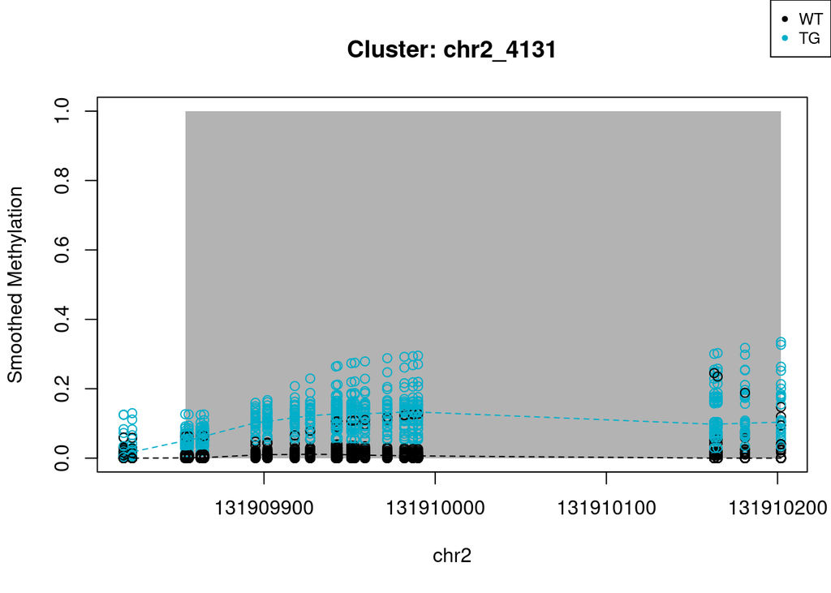

chr2_4131

seqnames

start

end

width

strand

cluster.id

position

DMR_info

inDMR

Location

p.val.Genotype

chr2

131909818

131909818

1

chr2_4131

202308

NA

FALSE

chr2:131909818

1.24e-02

chr2

131909823

131909823

1

chr2_4131

202309

NA

FALSE

chr2:131909823

5.34e-04

chr2

131909854

131909854

1

chr2_4131

202310

Start

TRUE

chr2:131909854

5.38e-11

chr2

131909856

131909856

1

chr2_4131

202311

NA

TRUE

chr2:131909856

2.17e-11

chr2

131909863

131909863

1

chr2_4131

202312

NA

TRUE

chr2:131909863

4.25e-12

chr2

131909865

131909865

1

chr2_4131

202313

NA

TRUE

chr2:131909865

4.72e-10

chr2

131909895

131909895

1

chr2_4131

202314

NA

TRUE

chr2:131909895

1.75e-07

chr2

131909902

131909902

1

chr2_4131

202315

NA

TRUE

chr2:131909902

1.98e-06

chr2

131909918

131909918

1

chr2_4131

202316

NA

TRUE

chr2:131909918

2.31e-05

chr2

131909927

131909927

1

chr2_4131

202317

NA

TRUE

chr2:131909927

8.16e-05

chr2

131909942

131909942

1

chr2_4131

202318

NA

TRUE

chr2:131909942

8.04e-04

chr2

131909943

131909943

1

chr2_4131

202319

NA

TRUE

chr2:131909943

1.44e-03

chr2

131909951

131909951

1

chr2_4131

202320

NA

TRUE

chr2:131909951

1.14e-03

chr2

131909953

131909953

1

chr2_4131

202321

NA

TRUE

chr2:131909953

1.07e-03

chr2

131909959

131909959

1

chr2_4131

202322

NA

TRUE

chr2:131909959

9.03e-04

chr2

131909972

131909972

1

chr2_4131

202323

NA

TRUE

chr2:131909972

7.73e-04

chr2

131909982

131909982

1

chr2_4131

202324

NA

TRUE

chr2:131909982

1.00e-03

chr2

131909987

131909987

1

chr2_4131

202325

NA

TRUE

chr2:131909987

7.85e-04

chr2

131909990

131909990

1

chr2_4131

202326

NA

TRUE

chr2:131909990

7.20e-04

chr2

131910163

131910163

1

chr2_4131

202327

NA

TRUE

chr2:131910163

3.84e-07

chr2

131910165

131910165

1

chr2_4131

202328

NA

TRUE

chr2:131910165

3.52e-07

chr2

131910181

131910181

1

chr2_4131

202329

NA

TRUE

chr2:131910181

3.31e-07

chr2

131910202

131910202

1

chr2_4131

202330

End

TRUE

chr2:131910202

8.81e-07

# Genotype*Age

[1] “No DMRs found”

# Pathology

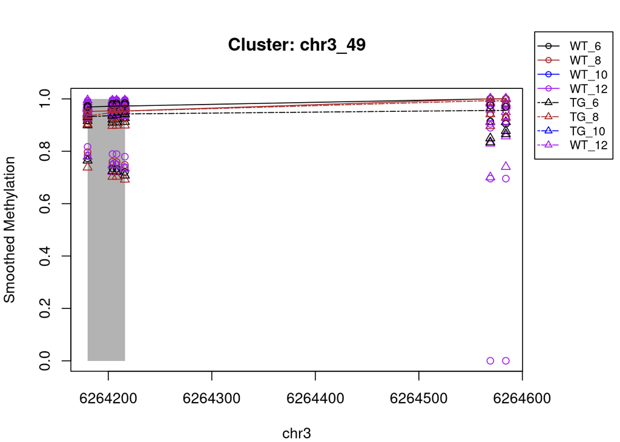

chr3_49

seqnames

start

end

width

strand

cluster.id

position

DMR_info

inDMR

Location

p.val.Pathology

chr3

6264180

6264180

1

chr3_49

619486

Start

TRUE

chr3:6264180

0.266

chr3

6264204

6264204

1

chr3_49

619487

NA

TRUE

chr3:6264204

0.289

chr3

6264208

6264208

1

chr3_49

619488

NA

TRUE

chr3:6264208

0.317

chr3

6264216

6264216

1

chr3_49

619489

End

TRUE

chr3:6264216

0.374

chr3

6264569

6264569

1

chr3_49

619490

NA

FALSE

chr3:6264569

0.944

chr3

6264584

6264584

1

chr3_49

619491

NA

FALSE

chr3:6264584

0.958

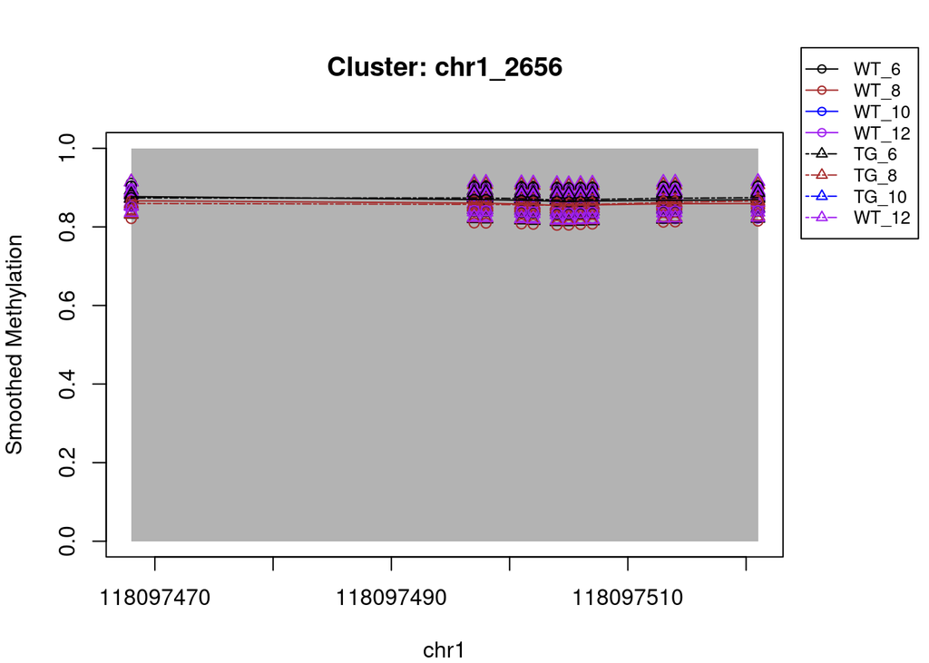

chr1_2656

seqnames

start

end

width

strand

cluster.id

position

DMR_info

inDMR

Location

p.val.Pathology

chr1

118097468

118097468

1

chr1_2656

1563184

Start

TRUE

chr1:118097468

0.893

chr1

118097497

118097497

1

chr1_2656

1563185

NA

TRUE

chr1:118097497

0.941

chr1

118097498

118097498

1

chr1_2656

1563186

NA

TRUE

chr1:118097498

0.945

chr1

118097501

118097501

1

chr1_2656

1563187

NA

TRUE

chr1:118097501

0.960

chr1

118097502

118097502

1

chr1_2656

1563188

NA

TRUE

chr1:118097502

0.964

chr1

118097504

118097504

1

chr1_2656

1563189

NA

TRUE

chr1:118097504

0.962

chr1

118097505

118097505

1

chr1_2656

1563190

NA

TRUE

chr1:118097505

0.957

chr1

118097506

118097506

1

chr1_2656

1563191

NA

TRUE

chr1:118097506

0.954

chr1

118097507

118097507

1

chr1_2656

1563192

NA

TRUE

chr1:118097507

0.955

chr1

118097513

118097513

1

chr1_2656

1563193

NA

TRUE

chr1:118097513

0.996

chr1

118097514

118097514

1

chr1_2656

1563194

NA

TRUE

chr1:118097514

0.999

chr1

118097521

118097521

1

chr1_2656

1563195

End

TRUE

chr1:118097521

0.974

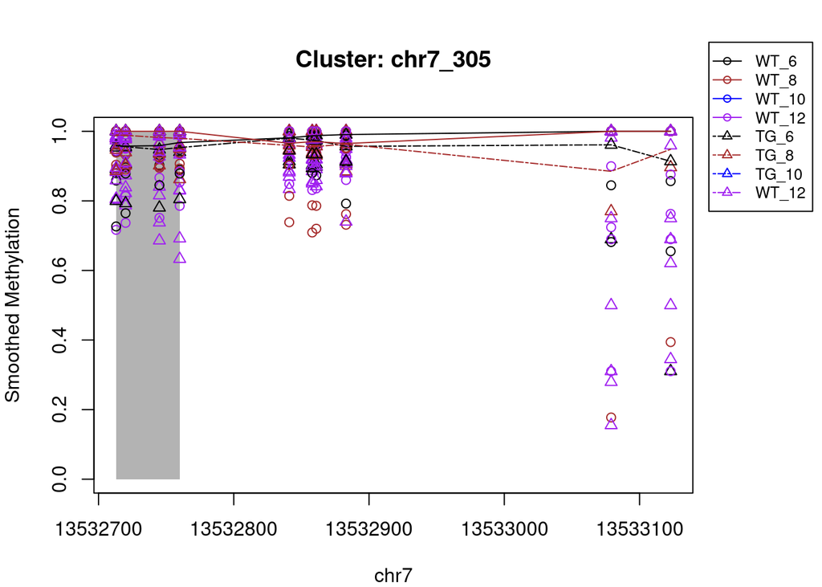

chr7_305

seqnames

start

end

width

strand

cluster.id

position

DMR_info

inDMR

Location

p.val.Pathology

chr7

13532713

13532713

1

chr7_305

440061

Start

TRUE

chr7:13532713

0.529

chr7

13532720

13532720

1

chr7_305

440062

NA

TRUE

chr7:13532720

0.522

chr7

13532745

13532745

1

chr7_305

440063

NA

TRUE

chr7:13532745

0.517

chr7

13532760

13532760

1

chr7_305

440064

End

TRUE

chr7:13532760

0.512

chr7

13532841

13532841

1

chr7_305

440065

NA

FALSE

chr7:13532841

0.514

chr7

13532858

13532858

1

chr7_305

440066

NA

FALSE

chr7:13532858

0.468

chr7

13532861

13532861

1

chr7_305

440067

NA

FALSE

chr7:13532861

0.460

chr7

13532883

13532883

1

chr7_305

440068

NA

FALSE

chr7:13532883

0.419

chr7

13533079

13533079

1

chr7_305

440069

NA

FALSE

chr7:13533079

0.435

chr7

13533123

13533123

1

chr7_305

440070

NA

FALSE

chr7:13533123

0.441

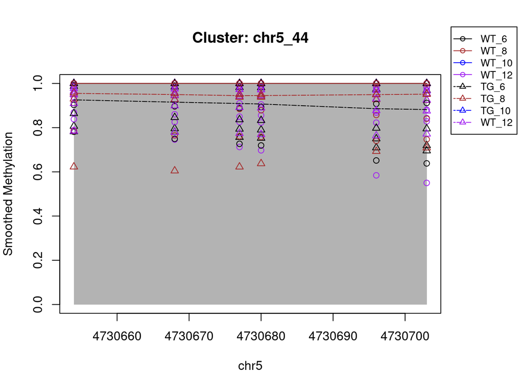

chr5_44

seqnames

start

end

width

strand

cluster.id

position

DMR_info

inDMR

Location

p.val.Pathology

chr5

4730654

4730654

1

chr5_44

68941

Start

TRUE

chr5:4730654

0.327

chr5

4730668

4730668

1

chr5_44

68942

NA

TRUE

chr5:4730668

0.329

chr5

4730677

4730677

1

chr5_44

68943

NA

TRUE

chr5:4730677

0.341

chr5

4730680

4730680

1

chr5_44

68944

NA

TRUE

chr5:4730680

0.344

chr5

4730696

4730696

1

chr5_44

68945

NA

TRUE

chr5:4730696

0.358

chr5

4730703

4730703

1

chr5_44

68946

End

TRUE

chr5:4730703

0.359

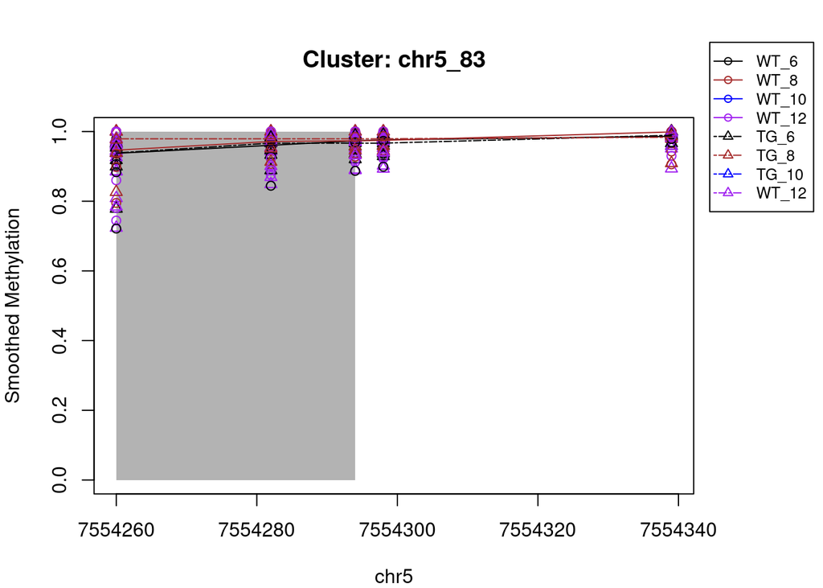

chr5_83

seqnames

start

end

width

strand

cluster.id

position

DMR_info

inDMR

Location

p.val.Pathology

chr5

7554260

7554260

1

chr5_83

127113

Start

TRUE

chr5:7554260

0.618

chr5

7554282

7554282

1

chr5_83

127114

NA

TRUE

chr5:7554282

0.965

chr5

7554294

7554294

1

chr5_83

127115

End

TRUE

chr5:7554294

0.936

chr5

7554298

7554298

1

chr5_83

127116

NA

FALSE

chr5:7554298

0.908

chr5

7554339

7554339

1

chr5_83

127117

NA

FALSE

chr5:7554339

0.385

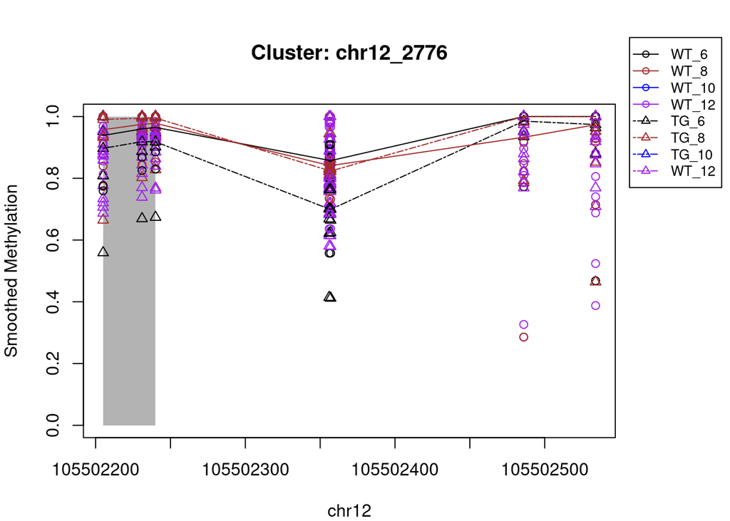

chr12_2776

seqnames

start

end

width

strand

cluster.id

position

DMR_info

inDMR

Location

p.val.Pathology

chr12

105502205

105502205

1

chr12_2776

1004480

Start

TRUE

chr12:105502205

0.4591

chr12

105502231

105502231

1

chr12_2776

1004481

NA

TRUE

chr12:105502231

0.4327

chr12

105502240

105502240

1

chr12_2776

1004482

End

TRUE

chr12:105502240

0.4208

chr12

105502356

105502356

1

chr12_2776

1004483

NA

FALSE

chr12:105502356

0.0249

chr12

105502357

105502357

1

chr12_2776

1004484

NA

FALSE

chr12:105502357

0.0248

chr12

105502486

105502486

1

chr12_2776

1004485

NA

FALSE

chr12:105502486

0.6757

chr12

105502534

105502534

1

chr12_2776

1004486

NA

FALSE

chr12:105502534

0.8265

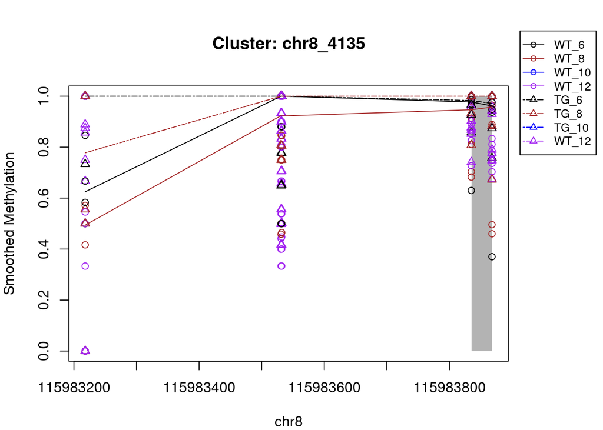

chr8_4135

seqnames

start

end

width

strand

cluster.id

position

DMR_info

inDMR

Location

p.val.Pathology

chr8

115983218

115983218

1

chr8_4135

697484

NA

FALSE

chr8:115983218

0.141

chr8

115983531

115983531

1

chr8_4135

697485

NA

FALSE

chr8:115983531

0.414

chr8

115983532

115983532

1

chr8_4135

697486

NA

FALSE

chr8:115983532

0.413

chr8

115983835

115983835

1

chr8_4135

697487

Start

TRUE

chr8:115983835

0.583

chr8

115983868

115983868

1

chr8_4135

697488

End

TRUE

chr8:115983868

0.611

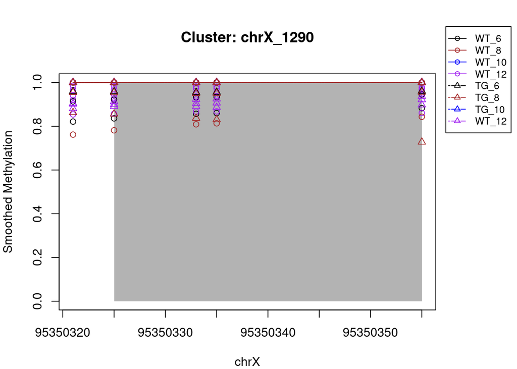

chrX_1290

seqnames

start

end

width

strand

cluster.id

position

DMR_info

inDMR

Location

p.val.Pathology

chrX

95350321

95350321

1

chrX_1290

517583

NA

FALSE

chrX:95350321

0.767

chrX

95350325

95350325

1

chrX_1290

517584

Start

TRUE

chrX:95350325

0.773

chrX

95350333

95350333

1

chrX_1290

517585

NA

TRUE

chrX:95350333

0.787

chrX

95350335

95350335

1

chrX_1290

517586

NA

TRUE

chrX:95350335

0.789

chrX

95350355

95350355

1

chrX_1290

517587

End

TRUE

chrX:95350355

0.803

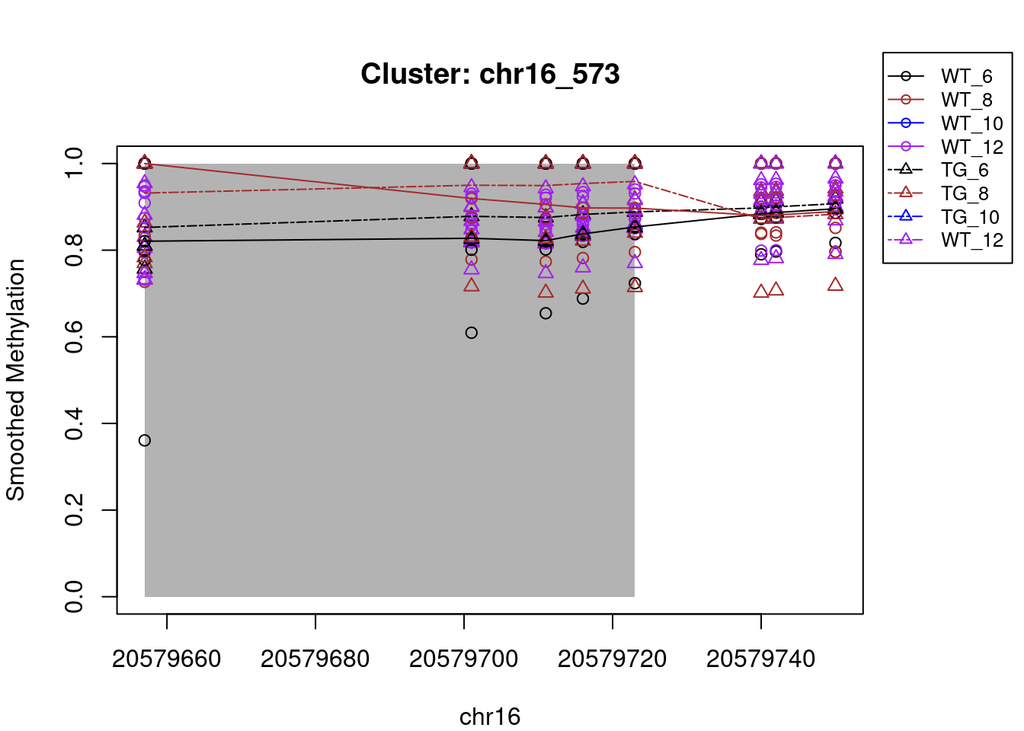

chr16_573

seqnames

start

end

width

strand

cluster.id

position

DMR_info

inDMR

Location

p.val.Pathology

chr16

20579657

20579657

1

chr16_573

958019

Start

TRUE

chr16:20579657

0.271

chr16

20579701

20579701

1

chr16_573

958020

NA

TRUE

chr16:20579701

0.130

chr16

20579711

20579711

1

chr16_573

958021

NA

TRUE

chr16:20579711

0.127

chr16

20579716

20579716

1

chr16_573

958022

NA

TRUE

chr16:20579716

0.128

chr16

20579723

20579723

1

chr16_573

958023

End

TRUE

chr16:20579723

0.129

chr16

20579740

20579740

1

chr16_573

958024

NA

FALSE

chr16:20579740

0.657

chr16

20579742

20579742

1

chr16_573

958025

NA

FALSE

chr16:20579742

0.656

chr16

20579750

20579750

1

chr16_573

958026

NA

FALSE

chr16:20579750

0.656

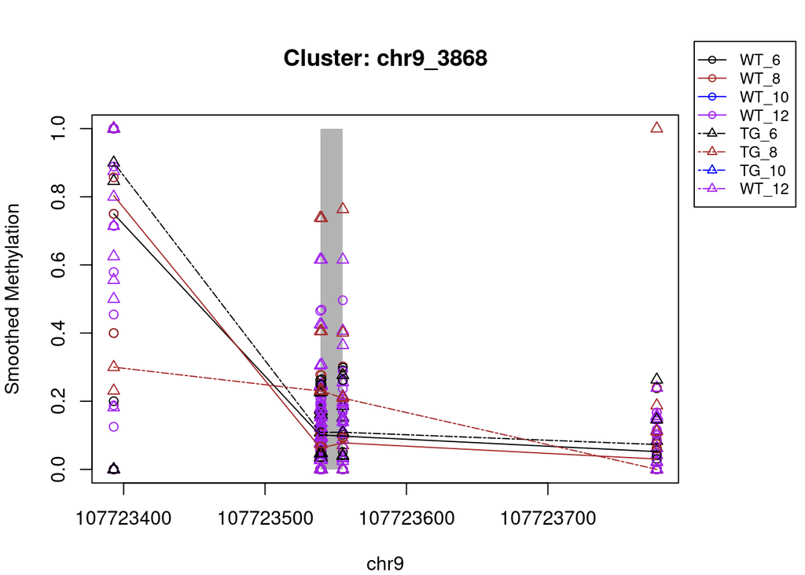

chr9_3868

seqnames

start

end

width

strand

cluster.id

position

DMR_info

inDMR

Location

p.val.Pathology

chr9

107723393

107723393

1

chr9_3868

884370

NA

FALSE

chr9:107723393

0.683

chr9

107723539

107723539

1

chr9_3868

884371

Start

TRUE

chr9:107723539

0.784

chr9

107723540

107723540

1

chr9_3868

884372

NA

TRUE

chr9:107723540

0.782

chr9

107723555

107723555

1

chr9_3868

884373

End

TRUE

chr9:107723555

0.745

chr9

107723777

107723777

1

chr9_3868

884374

NA

FALSE

chr9:107723777

0.748